# UADE - Maestria TIC - Ciencia de Datos - Modelo de predicción para aprobación de Tarjetas de Crédito

#### 4.3.9 - Variable: NAME_EDUCATION_TYPE

##### NAME_EDUCATION_TYPE

Para conocere la distribución de la muestra graficamos con barras diferentes categorías:

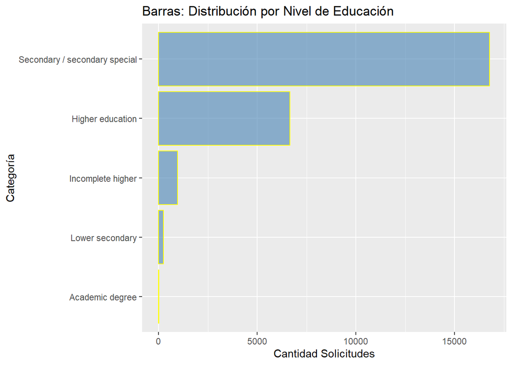

```r
catIncomeType <- table(dfCreditCard$NAME_EDUCATION_TYPE)
dfCatIncomeType <- as.data.frame(catIncomeType)
names(dfCatIncomeType) <- c("Categoria","Cantidad")
# Ordenamos
dfCatIncomeType <- transform(dfCatIncomeType, Categoria=reorder(Categoria, Cantidad))
ggplot(dfCatIncomeType) +
  geom_bar(
    aes(x=Categoria, y=Cantidad),
    stat="identity",
    fill="steel blue",
    col= "yellow",
    alpha= .6) +
    labs(title="Barras: Distribución por Nivel de Educación", x="Categoría", y="Cantidad Solicitudes") +
    coord_flip()
```

##### NAME_EDUCATION_TYPE vs APPROVE

Verificamos si podría existir alguna relación entre ambas variables mediante un gráfico de barras apiladas.

```r
print(levels(dfCreditCard$NAME_EDUCATION_TYPE))
```

```
## [1] "Academic degree"               "Higher education"
## [3] "Incomplete higher"             "Lower secondary"
## [5] "Secondary / secondary special"
```

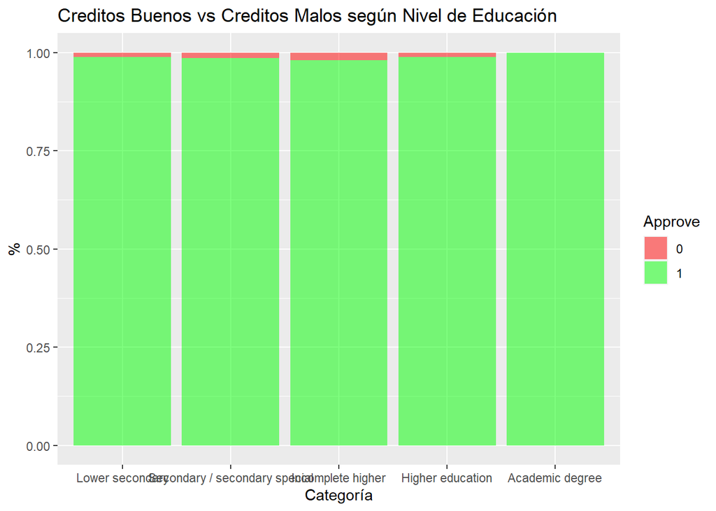

```r
dfCreditCard$NAME_EDUCATION_TYPE <- factor(dfCreditCard$NAME_EDUCATION_TYPE, levels = c("Lower secondary","Secondary / secondary special","Incomplete higher", "Higher education", "Academic degree"), ordered = TRUE)
ggplot(dfCreditCard) +
  geom_bar(aes(x=NAME_EDUCATION_TYPE, fill=Approve), position="fill", alpha=.5) +
  labs(title="Creditos Buenos vs Creditos Malos según Nivel de Educación", x="Categoría", y="%") +
  scale_fill_manual(values= c("0"= "red", "1"="green"))
```

Visualizamos que podría existir una relación entre el nivel de educación y la calidad crediticia. Podría ser un posible predictor.

#### 4.3.10 - Variable: NAME_FAMILY_STATUS

##### NAME_FAMILY_STATUS

Para conocere la distribución de la muestra graficamos con barras diferentes categorías:

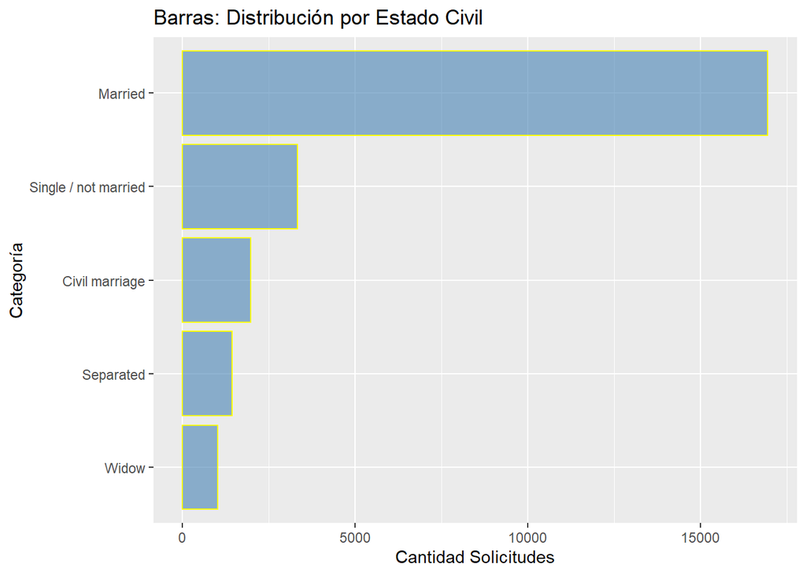

```r
catIncomeType <- table(dfCreditCard$NAME_FAMILY_STATUS)
dfCatIncomeType <- as.data.frame(catIncomeType)
names(dfCatIncomeType) <- c("Categoria","Cantidad")
# Ordenamos
dfCatIncomeType <- transform(dfCatIncomeType, Categoria=reorder(Categoria, Cantidad))
ggplot(dfCatIncomeType) +
  geom_bar(
    aes(x=Categoria, y=Cantidad),
    stat="identity",
    fill="steel blue",
    col= "yellow",
    alpha= .6) +
    labs(title="Barras: Distribución por Estado Civil", x="Categoría", y="Cantidad Solicitudes") +
    coord_flip()
```

##### NAME_FAMILY_STATUS vs APPROVE

Verificamos si podría existir alguna relación entre ambas variables mediante un gráfico de barras apiladas.

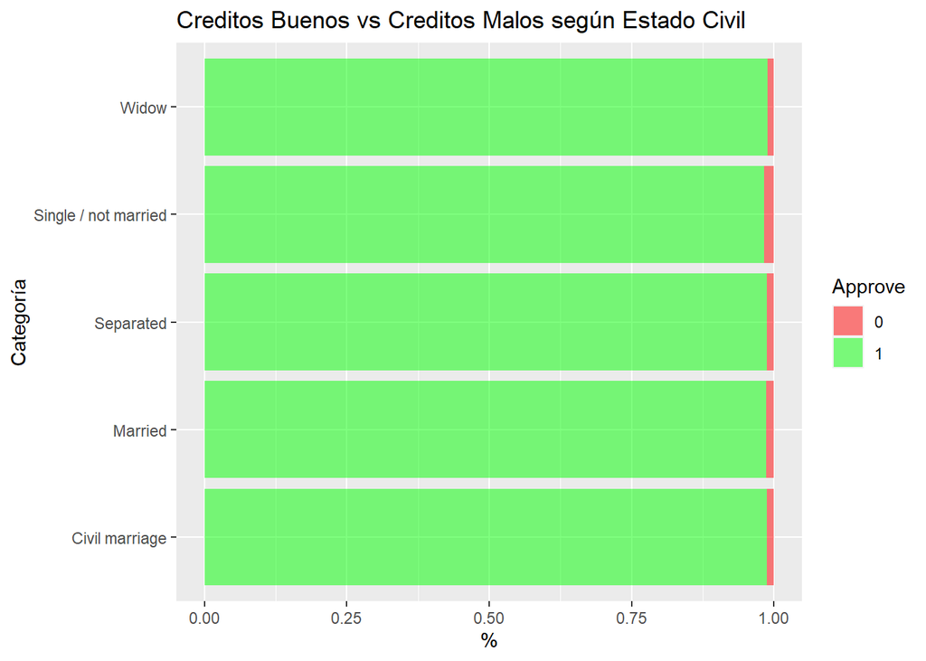

```r
ggplot(dfCreditCard) +
  geom_bar(aes(x=NAME_FAMILY_STATUS, fill=Approve), position="fill", alpha=.5) +
  labs(title="Creditos Buenos vs Creditos Malos según Estado Civil", x="Categoría", y="%") +
  scale_fill_manual(values= c("0"= "red", "1"="green")) +
    coord_flip()
```

Se visualiza una ligera relación entre las variables. Podría ser un posible predictor.

#### 4.3.11 - Variable: NAME_HOUSING_TYPE

##### NAME_HOUSING_TYPE

Para conocere la distribución de la muestra graficamos con barras diferentes categorías:

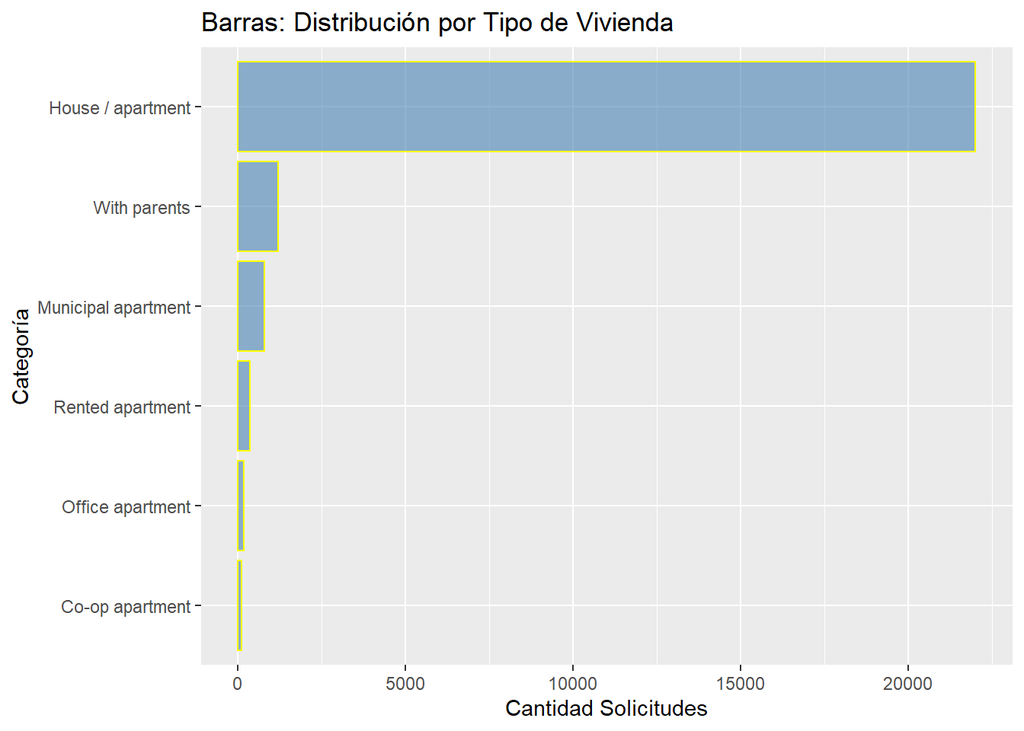

```r
catIncomeType <- table(dfCreditCard$NAME_HOUSING_TYPE)
dfCatIncomeType <- as.data.frame(catIncomeType)
names(dfCatIncomeType) <- c("Categoria","Cantidad")
# Ordenamos
dfCatIncomeType <- transform(dfCatIncomeType, Categoria=reorder(Categoria, Cantidad))
ggplot(dfCatIncomeType) +
  geom_bar(
    aes(x=Categoria, y=Cantidad),
    stat="identity",
    fill="steel blue",
    col= "yellow",
    alpha= .6) +
    labs(title="Barras: Distribución por Tipo de Vivienda", x="Categoría", y="Cantidad Solicitudes") +
    coord_flip()
```

##### NAME_HOUSING_TYPE vs APPROVE

Verificamos si podría existir alguna relación entre ambas variables mediante un gráfico de barras apiladas.

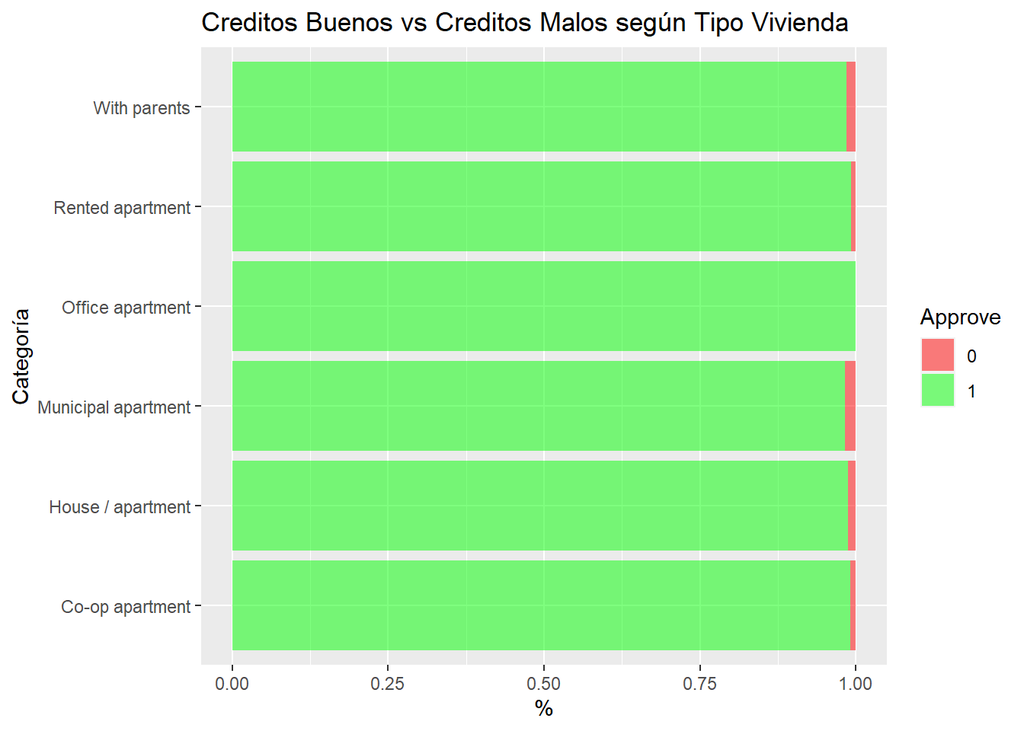

```r
ggplot(dfCreditCard) +
  geom_bar(aes(x=NAME_HOUSING_TYPE, fill=Approve), position="fill", alpha=.5) +
  labs(title="Creditos Buenos vs Creditos Malos según Tipo Vivienda", x="Categoría", y="%") +
  scale_fill_manual(values= c("0"= "red", "1"="green")) +
    coord_flip()
```

Se visualiza una relación entre las variables. Podría ser un posible predictor.

#### 4.3.12 - Variable: OCCUPATION_TYPE

##### OCCUPATION_TYPE

Como se observó en el summary, la categoría tiene datos incompletos.

```r
summary(dfCreditCard$OCCUPATION_TYPE)
```

```
##                                 Accountants        Cleaning staff
##                  7629                   853                   385
##         Cooking staff            Core staff               Drivers
##                   449                  2381                  1504
## High skill tech staff              HR staff              IT staff
##                   950                    53                    46
##              Laborers    Low-skill Laborers              Managers
##                  4293                   123                  2008
##        Medicine staff Private service staff         Realty agents
##                   796                   235                    47
##           Sales staff           Secretaries        Security staff
##                  2328                    98                   406
##  Waiters/barmen staff
##                    88
```

No podemos consultar a negocio si son solicitudes incompletas o representa la categoría “Otros”. A los fines del ejercicio se decide etiquetarlos como “Otros”.

```r
levels(dfCreditCard$OCCUPATION_TYPE)[levels(dfCreditCard$OCCUPATION_TYPE) == ""] <- "Other"
summary(dfCreditCard$OCCUPATION_TYPE)
```

```
##                 Other           Accountants        Cleaning staff
##                  7629                   853                   385
##         Cooking staff            Core staff               Drivers
##                   449                  2381                  1504
## High skill tech staff              HR staff              IT staff
##                   950                    53                    46
##              Laborers    Low-skill Laborers              Managers
##                  4293                   123                  2008
##        Medicine staff Private service staff         Realty agents
##                   796                   235                    47
##           Sales staff           Secretaries        Security staff
##                  2328                    98                   406
##  Waiters/barmen staff
##                    88
```

Para conocere la distribución de la muestra graficamos con barras diferentes categorías:

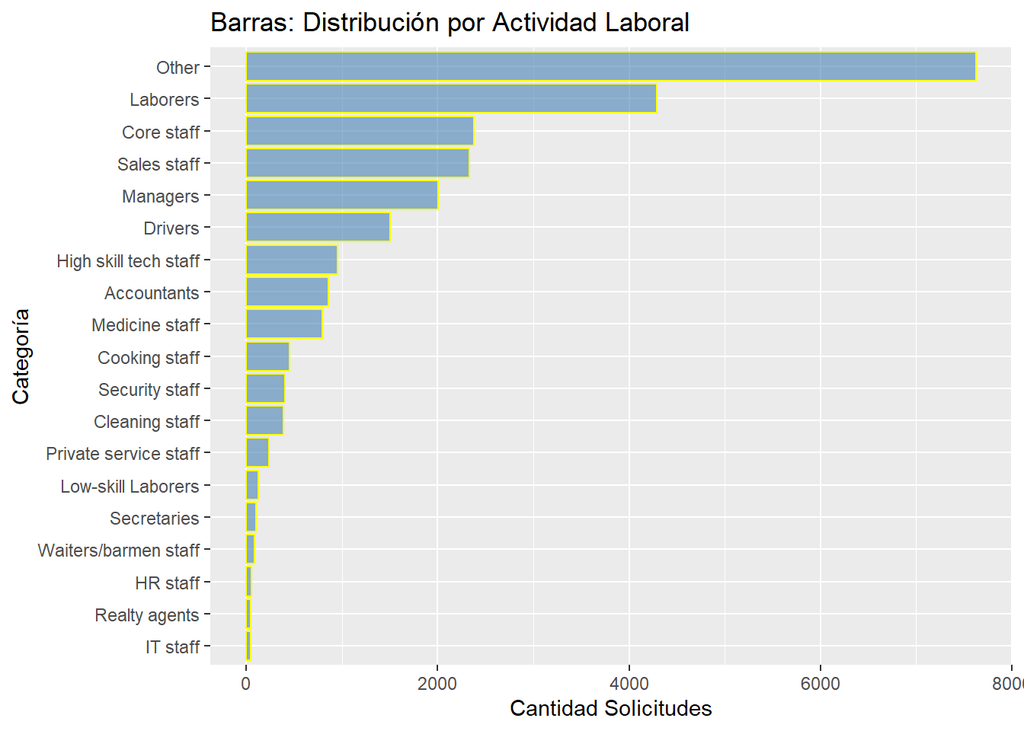

```r
catIncomeType <- table(dfCreditCard$OCCUPATION_TYPE)
dfCatIncomeType <- as.data.frame(catIncomeType)
names(dfCatIncomeType) <- c("Categoria","Cantidad")
# Ordenamos
dfCatIncomeType <- transform(dfCatIncomeType, Categoria=reorder(Categoria, Cantidad))
ggplot(dfCatIncomeType) +
  geom_bar(
    aes(x=Categoria, y=Cantidad),
    stat="identity",
    fill="steel blue",
    col= "yellow",
    alpha= .6) +
    labs(title="Barras: Distribución por Actividad Laboral", x="Categoría", y="Cantidad Solicitudes") +
    coord_flip()
```

En esta variable existen muchas categorías. Se deberá evaluar si afecta o no al modelo.

##### OCCUPATION_TYPE vs APPROVE

Verificamos si podría existir alguna relación entre ambas variables mediante un gráfico de barras apiladas.

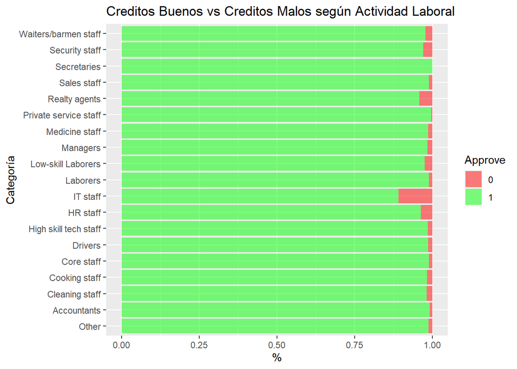

```r
ggplot(dfCreditCard) +
  geom_bar(aes(x=OCCUPATION_TYPE, fill=Approve), position="fill", alpha=.5) +
  labs(title="Creditos Buenos vs Creditos Malos según Actividad Laboral", x="Categoría", y="%") +
  scale_fill_manual(values= c("0"= "red", "1"="green")) +
    coord_flip()
```

Se visualiza una relación entre las variables. Podría ser un posible predictor.

# Construcción del Modelo Predictivo

## 1 - Preparar los datasets de Training y de Testing

Dividimos el set de datos en un 80% para entrenamiento y un 20% para prueba.

```r
muestra <- floor(nrow(dfCreditCard) * 0.8)
trainingIndex <- sample(nrow(dfCreditCard), muestra, replace=FALSE)
testIndex <- seq_len(nrow(dfCreditCard))[!(seq_len(nrow(dfCreditCard)) %in% trainingIndex)]
dfTrainLR <- dfCreditCard[trainingIndex,]
dfTestLR <- dfCreditCard[testIndex,]
```

```r
summary(dfTrainLR)
```

```
##        ID          CODE_GENDER FLAG_OWN_CAR FLAG_OWN_REALTY  CNT_CHILDREN
##  Min.   :5008804   F:13186     N:12263      N: 6742         Min.   : 0.0000
##  1st Qu.:5045521   M: 6551     Y: 7474      Y:12995         1st Qu.: 0.0000
##  Median :5069509                                            Median : 0.0000
##  Mean   :5078994                                            Mean   : 0.4159
##  3rd Qu.:5115548                                            3rd Qu.: 1.0000
##  Max.   :5150487                                            Max.   :19.0000
##
##  AMT_INCOME_TOTAL              NAME_INCOME_TYPE
##  Min.   :  27000   Commercial associate: 4688
##  1st Qu.: 121500   Pensioner           : 3305
##  Median : 157500   State servant       : 1562
##  Mean   : 186881   Working             :10182
##  3rd Qu.: 225000
##  Max.   :1575000
##
##                     NAME_EDUCATION_TYPE            NAME_FAMILY_STATUS
##  Lower secondary              :  195    Civil marriage      : 1592
##  Secondary / secondary special:13435    Married             :13566
##  Incomplete higher            :  770    Separated           : 1157
##  Higher education             : 5320    Single / not married: 2607
##  Academic degree              :   17    Widow               :  815
##
##
##            NAME_HOUSING_TYPE   DAYS_BIRTH     DAYS_EMPLOYED    FLAG_MOBIL
##  Co-op apartment    :   87   Min.   :-25152   Min.   :-15713   1:19737
##  House / apartment  :17628   1st Qu.:-19453   1st Qu.: -3170
##  Municipal apartment:  607   Median :-15653   Median : -1567
##  Office apartment   :  148   Mean   :-16022   Mean   : 58677
##  Rented apartment   :  290   3rd Qu.:-12544   3rd Qu.:  -407
##  With parents       :  977   Max.   : -7489   Max.   :365243
##
##  FLAG_WORK_PHONE FLAG_PHONE FLAG_EMAIL    OCCUPATION_TYPE CNT_FAM_MEMBERS
##  0:15229         0:13933    0:17939    Other      :6087   Min.   : 1.000
##  1: 4508         1: 5804    1: 1798    Laborers   :3423   1st Qu.: 2.000
##                                        Core staff :1894   Median : 2.000
##                                        Sales staff:1851   Mean   : 2.185
##                                        Managers   :1600   3rd Qu.: 3.000
##                                        Drivers    :1180   Max.   :20.000
##                                        (Other)    :3702
##  MONTHS_BALANCE     STATUS      Approve        AGE        YEARS_EMPLOYED
##  Min.   :0      C      :10375   0:  266   Min.   :20.00   Min.   : 0.000
##  1st Qu.:0      0      : 5497   1:19471   1st Qu.:34.00   1st Qu.: 3.000
##  Median :0      X      : 3599             Median :42.00   Median : 4.000
##  Mean   :0      1      :  193             Mean   :43.39   Mean   : 6.346
##  3rd Qu.:0      5      :   52             3rd Qu.:53.00   3rd Qu.: 8.000
##  Max.   :0      2      :   13             Max.   :68.00   Max.   :43.000
##                 (Other):    8
```

Como la variable objetivo está muy desbalanceada se decidió aplicar la técnica SMOTE (Synthetic Minority Over-Sampling Technique) para mejorar el balance.

Aplicamos la técnica SMOTE, con un over de 500% para el grupo minoritario y un under de 150% para el grupo mayoritario. Con un un k=5 que representa el número de vecinos cercanos que va a utilzar el algoritmo. La cantidad de vecinos cercanos tomamos la que utiliza la técnica por defecto, mientras que los % de grupos minoritarios y mayoritarios los fuimos ajustamos un par de veces hasta que nos dió balanceada la cantidad de Creditos Buenos y Creditos Malos.

```r
dfTrainLR <- SMOTE(Approve ~ ., dfTrainLR, perc.over = 500, k=5, perc.under=150)
str(dfTrainLR)
```

```
## 'data.frame':    3591 obs. of  23 variables:
##  $ ID                 : num  5140046 5143234 5022917 5125819 5117423 ...
##  $ CODE_GENDER        : Factor w/ 2 levels "F","M": 1 1 1 1 2 1 1 1 1 2 ...
##  $ FLAG_OWN_CAR       : Factor w/ 2 levels "N","Y": 1 2 1 1 2 1 1 1 1 1 ...
##  $ FLAG_OWN_REALTY    : Factor w/ 2 levels "N","Y": 1 2 2 2 1 2 2 2 2 2 ...
##  $ CNT_CHILDREN       : num  0 1 0 2 3 0 0 0 2 0 ...
##  $ AMT_INCOME_TOTAL   : num  90000 1575000 225000 157500 180000 ...
##  $ NAME_INCOME_TYPE   : Factor w/ 4 levels "Commercial associate",..: 2 1 4 1 4 2 3 2 4 4 ...
##  $ NAME_EDUCATION_TYPE: Ord.factor w/ 5 levels "Lower secondary"<..: 2 4 4 4 2 2 2 2 2 4 ...
##  $ NAME_FAMILY_STATUS : Factor w/ 5 levels "Civil marriage",..: 5 4 4 2 2 2 2 2 2 4 ...
##  $ NAME_HOUSING_TYPE  : Factor w/ 6 levels "Co-op apartment",..: 2 2 2 2 2 2 2 2 2 2 ...
##  $ DAYS_BIRTH         : num  -23240 -10142 -12195 -11221 -10048 ...
##  $ DAYS_EMPLOYED      : num  365243 -2479 -2592 -4244 -3475 ...
##  $ FLAG_MOBIL         : Factor w/ 1 level "1": 1 1 1 1 1 1 1 1 1 1 ...
##  $ FLAG_WORK_PHONE    : Factor w/ 2 levels "0","1": 1 1 1 2 2 1 1 1 1 1 ...
##  $ FLAG_PHONE         : Factor w/ 2 levels "0","1": 1 1 2 2 1 2 1 1 1 1 ...
##  $ FLAG_EMAIL         : Factor w/ 2 levels "0","1": 1 1 1 1 1 1 2 1 1 1 ...
##  $ OCCUPATION_TYPE    : Factor w/ 19 levels "Other","Accountants",..: 1 12 12 10 1 1 1 1 16 10 ...
##  $ CNT_FAM_MEMBERS    : num  1 2 1 4 5 2 2 2 4 1 ...
##  $ MONTHS_BALANCE     : num  0 0 0 0 0 0 0 0 0 0 ...
##  $ STATUS             : Factor w/ 8 levels "0","1","2","3",..: 8 1 7 7 7 7 1 7 7 1 ...
##  $ Approve            : Factor w/ 2 levels "0","1": 2 2 2 2 2 2 2 2 2 2 ...
##  $ AGE                : num  63 27 33 30 27 62 48 55 38 25 ...
##  $ YEARS_EMPLOYED     : num  4 6 7 11 9 4 6 4 3 2 ...
```

```r
summary(dfTrainLR)
```

```
##        ID          CODE_GENDER FLAG_OWN_CAR FLAG_OWN_REALTY  CNT_CHILDREN
##  Min.   :5008804   F:2431      N:2233       N:1421          Min.   :0.0000
##  1st Qu.:5046179   M:1160      Y:1358       Y:2170          1st Qu.:0.0000
##  Median :5077617                                            Median :0.0000
##  Mean   :5079155                                            Mean   :0.3771
##  3rd Qu.:5114713                                            3rd Qu.:0.8224
##  Max.   :5150483                                            Max.   :5.0000
##
##  AMT_INCOME_TOTAL              NAME_INCOME_TYPE
##  Min.   :  33300   Commercial associate: 701
##  1st Qu.: 112620   Pensioner           :1075
##  Median : 157500   State servant       : 179
##  Mean   : 181845   Working             :1636
##  3rd Qu.: 225000
##  Max.   :1575000
##
##                     NAME_EDUCATION_TYPE            NAME_FAMILY_STATUS
##  Lower secondary              :  12     Civil marriage      : 213
##  Secondary / secondary special:1546     Married             :2669
##  Incomplete higher            : 112     Separated           : 176
##  Higher education             : 588     Single / not married: 416
##  Academic degree              :   3     Widow               : 117
##  NA's                         :1330
##
##            NAME_HOUSING_TYPE   DAYS_BIRTH     DAYS_EMPLOYED    FLAG_MOBIL
##  Co-op apartment    :  14    Min.   :-24963   Min.   :-15227   1:3591
##  House / apartment  :3137    1st Qu.:-20469   1st Qu.: -2175
##  Municipal apartment: 231    Median :-16959   Median :  -528
##  Office apartment   :  16    Mean   :-16784   Mean   :101994
##  Rented apartment   :  47    3rd Qu.:-13248   3rd Qu.:225645
##  With parents       : 146    Max.   : -7757   Max.   :365243
##
##  FLAG_WORK_PHONE FLAG_PHONE FLAG_EMAIL      OCCUPATION_TYPE CNT_FAM_MEMBERS
##  0:2790          0:2564     0:3329     Other        :1452   Min.   :1.000
##  1: 801          1:1027     1: 262     Laborers     : 505   1st Qu.:2.000
##                                        Managers     : 272   Median :2.000
##                                        Sales staff  : 270   Mean   :2.187
##                                        Core staff   : 251   3rd Qu.:2.610
##                                        Cooking staff: 173   Max.   :7.000
##                                        (Other)      : 668
##  MONTHS_BALANCE     STATUS     Approve       AGE        YEARS_EMPLOYED
##  Min.   :0      1      :1229   0:1596   Min.   :21.00   Min.   : 0.000
##  1st Qu.:0      C      :1076   1:1995   1st Qu.:36.00   1st Qu.: 2.745
##  Median :0      0      : 566            Median :46.00   Median : 4.000
##  Mean   :0      X      : 353            Mean   :45.50   Mean   : 5.591
##  3rd Qu.:0      5      : 176            3rd Qu.:55.68   3rd Qu.: 7.000
##  Max.   :0      4      : 142            Max.   :68.00   Max.   :41.000
##                 (Other):  49
```

## 2 - Fittiamos el modelo de Regresión Logística

Como el problema planteado es de clasificación binaria, es decir intentamos predecir una variable dicotómica, el modelo a probar primero es la Regresión Logística.

### 2.1 - Seleccionamos Predictores en base al análisis

Como primera aproximación vamos a utilizar como predictor la variable *OCCUPATION_TYPE* que es la que mayor relación con la variable objetivo mostraba en los gráficos.

```r
objetivo <- "Approve"
predictores <- c("OCCUPATION_TYPE")
```

### 2.2 - Creamos la formula del modelo

```r
formula <- paste(objetivo, paste(predictores, collapse = " + "), sep=" ~ ")
print(formula)
```

```
## [1] "Approve ~ OCCUPATION_TYPE"
```

### 2.3 - Entrenamos el modelo

```r
modeloLR <- glm(formula, data=dfTrainLR, family=binomial(link="logit"))
```

#### 2.3.1 - Visualizamos el summary del modelo

```r
summary(modeloLR)
```

```
##
## Call:
## glm(formula = formula, family = binomial(link = "logit"), data = dfTrainLR)
##
## Deviance Residuals:
##     Min       1Q   Median       3Q      Max
## -1.6345  -1.0747   0.7812   0.9209   1.7877
##
## Coefficients:
##                                       Estimate Std. Error z value Pr(>|z|)
## (Intercept)                           -0.24642    0.05289  -4.659 3.17e-06 ***
## OCCUPATION_TYPEAccountants             1.19550    0.24616   4.857 1.19e-06 ***
## OCCUPATION_TYPECleaning staff          0.52267    0.28764   1.817   0.0692 .
## OCCUPATION_TYPECooking staff          -1.12549    0.19651  -5.727 1.02e-08 ***
## OCCUPATION_TYPECore staff              0.96960    0.14460   6.705 2.01e-11 ***
## OCCUPATION_TYPEDrivers                 1.01961    0.17281   5.900 3.63e-09 ***
## OCCUPATION_TYPEHigh skill tech staff   0.83948    0.19941   4.210 2.56e-05 ***
## OCCUPATION_TYPEHR staff                1.16271    0.83833   1.387   0.1655
## OCCUPATION_TYPEIT staff               -0.85219    0.66876  -1.274   0.2026
## OCCUPATION_TYPELaborers                1.09844    0.11065   9.927  < 2e-16 ***
## OCCUPATION_TYPELow-skill Laborers      0.55657    0.40047   1.390   0.1646
## OCCUPATION_TYPEManagers                0.88491    0.13803   6.411 1.45e-10 ***
## OCCUPATION_TYPEMedicine staff          0.55315    0.21750   2.543   0.0110 *
## OCCUPATION_TYPEPrivate service staff  14.81249  214.09672   0.069   0.9448
## OCCUPATION_TYPERealty agents           0.09227    0.55886   0.165   0.8689
## OCCUPATION_TYPESales staff             1.27704    0.14801   8.628  < 2e-16 ***
## OCCUPATION_TYPESecretaries            14.81249  333.64564   0.044   0.9646
## OCCUPATION_TYPESecurity staff          0.21133    0.27017   0.782   0.4341
## OCCUPATION_TYPEWaiters/barmen staff    0.06410    0.60784   0.105   0.9160
## ---
## Signif. codes:  0 '***' 0.001 '**' 0.01 '*' 0.05 '.' 0.1 ' ' 1
##
## (Dispersion parameter for binomial family taken to be 1)
##
##     Null deviance: 4933.8  on 3590  degrees of freedom
## Residual deviance: 4593.7  on 3572  degrees of freedom
## AIC: 4631.7
##
## Number of Fisher Scoring iterations: 13
```

#### 2.3.2 - Evaluamos el modelo

##### 2.3.2.1 - Plotear distribución de predicciones

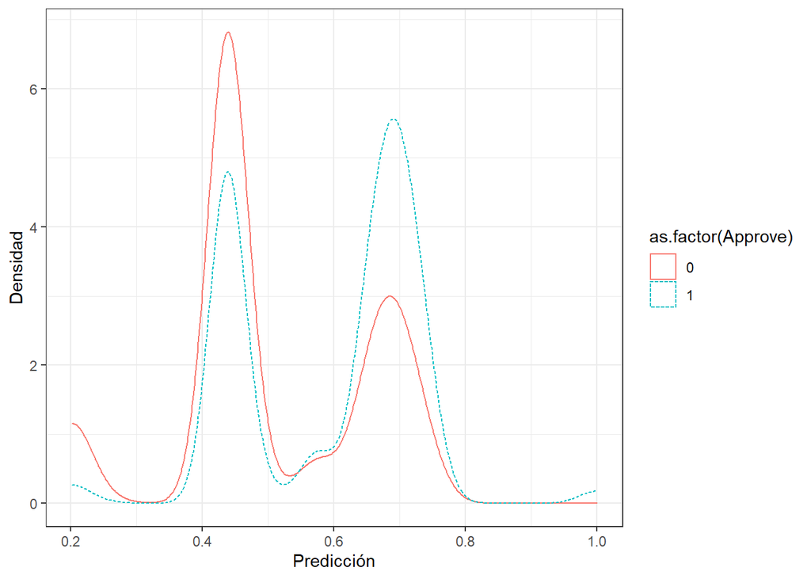

```r
dfTrainLR$pred <- predict(modeloLR, newdata= dfTrainLR, type="response")
dfTestLR$pred <- predict(modeloLR, newdata= dfTestLR, type="response")
ggplot(dfTrainLR) +
  geom_density(aes(x=pred, colour=as.factor(Approve), linetype=as.factor(Approve))) +
  xlab("Predicción") +
  ylab("Densidad") +
  theme_bw()
```

Se observan los los picos bien definidos y mucho ruido dentro de cada categoría.

##### 2.3.2.2 - Matriz de Confusión

Probamos con un umbral del 55%.

```r
thresh <- 0.55
predObj <-prediction(dfTrainLR$pred, dfTrainLR$Approve)
precObj <- performance(predObj, measure = "prec")
recObj <- performance(predObj, measure = "rec")
precision <- (precObj@y.values)[[1]]
prec.x <- (precObj@x.values)[[1]]
recall <- (recObj@y.values)[[1]]
pnull <- (length(which(dfTrainLR$Approve == 1)) / length(which(dfTrainLR$Approve != 2)))
pnull
```

```
## [1] 0.5555556
```

```r
ctab.test <- table(prediccion=as.numeric(dfTestLR$pred > thresh), datos=dfTestLR$Approve)
ctab.test
```

```
##           datos
## prediccion    0    1
##          0   25 1706
##          1   34 3170
```

```r
precision <- ctab.test[2,2]/sum(ctab.test[2,])
paste("Precision:", precision)
```

```
## [1] "Precision: 0.989388264669164"
```

```r
recall <- ctab.test[2,2]/sum(ctab.test[,2])
paste("Recall:",recall)
```

```
## [1] "Recall: 0.650123051681706"
```

```r
enrich <- precision / pnull
paste("Enrich:",enrich)
```

```
## [1] "Enrich: 1.78089887640449"
```

```r
PorcFalsosDetect <- ctab.test[1,1]/sum(ctab.test[,1])
PorcPositivosRech <- ctab.test[1,2]/sum(ctab.test[,2])
paste("% Falsos detectados: ", round(PorcFalsosDetect * 100, digits=2))
```

```
## [1] "% Falsos detectados:  42.37"
```

```r
paste("% Creditos buenos rechazados: ", round(PorcPositivosRech * 100, digits=2))
```

```
## [1] "% Creditos buenos rechazados:  34.99"
```

##### 2.3.2.3 - Curva ROC

Antes de decidir ajustar el umbral graficamos la curva ROC para entender las capacidades de predicción del modelo.

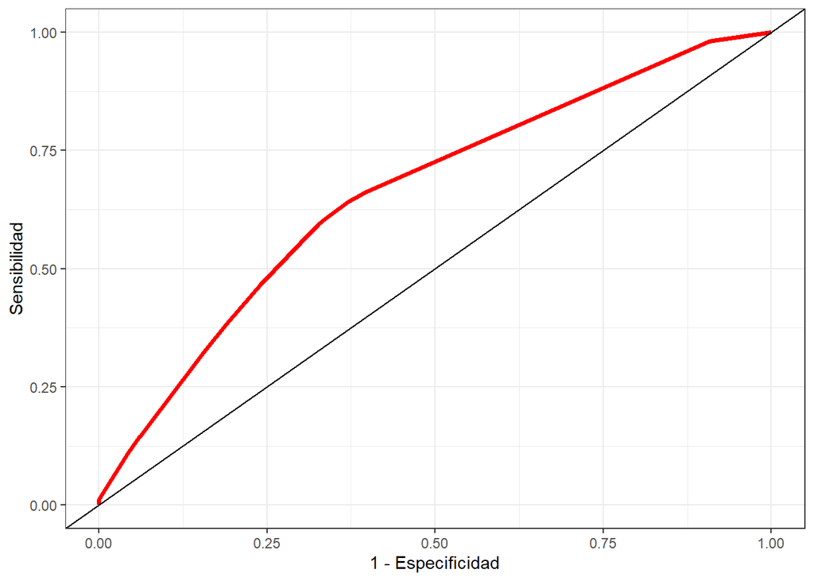

```r
sensObj <- performance(predObj, measure="sens")
specObj <- performance(predObj, measure="spec")
sensitivity <- (sensObj@y.values)[[1]]
specificity <- (specObj@y.values)[[1]]
dfplot <- data.frame(specm1=1-specificity, sens=sensitivity)
fig <- ggplot(dfplot, aes(x=specm1, y=sens))
fig <- fig + geom_line(color="red", size=1.25)
fig <- fig + geom_abline(aes(slope=1, intercept=0))
fig <- fig + theme_bw()
fig <- fig + xlab("1 - Especificidad")
fig <- fig + ylab("Sensibilidad")
fig
```

La capacidad de predicción de este modelo es muy baja. Vamos a Reentrenar el modelo con mayor cantidad de variables.

### 2.4 - Probamos re-entrenar el modelo

Probaremos con el resto de los predictores.

```r
predictores <- c("CODE_GENDER", "FLAG_OWN_CAR", "FLAG_OWN_REALTY", "AMT_INCOME_TOTAL", "NAME_INCOME_TYPE", "NAME_EDUCATION_TYPE", "NAME_FAMILY_STATUS", "NAME_HOUSING_TYPE", "FLAG_WORK_PHONE", "FLAG_PHONE", "FLAG_EMAIL", "OCCUPATION_TYPE", "CNT_FAM_MEMBERS", "AGE", "YEARS_EMPLOYED")

print("Predictores:")
```

```
## [1] "Predictores:"
```

```r
print(predictores)
```

```
##  [1] "CODE_GENDER"         "FLAG_OWN_CAR"        "FLAG_OWN_REALTY"
##  [4] "AMT_INCOME_TOTAL"    "NAME_INCOME_TYPE"    "NAME_EDUCATION_TYPE"
##  [7] "NAME_FAMILY_STATUS"  "NAME_HOUSING_TYPE"   "FLAG_WORK_PHONE"
## [10] "FLAG_PHONE"          "FLAG_EMAIL"          "OCCUPATION_TYPE"
## [13] "CNT_FAM_MEMBERS"     "AGE"                 "YEARS_EMPLOYED"
```

```r
formula <- paste(objetivo, paste(predictores, collapse = " + "), sep=" ~ ")
modeloLR <- glm(formula, data=dfTrainLR, family=binomial(link="logit"))
```

Visualizamos el summary del modelo.

```r
summary(modeloLR)
```

```
##
## Call:
## glm(formula = formula, family = binomial(link = "logit"), data = dfTrainLR)
##
## Deviance Residuals:
##     Min       1Q   Median       3Q      Max
## -2.4003   0.4047   0.4710   0.5266   1.0948
##
## Coefficients:
##                                          Estimate Std. Error z value Pr(>|z|)
## (Intercept)                             5.536e+00  2.771e+02   0.020   0.9841
## CODE_GENDERM                           -1.701e-01  1.707e-01  -0.996   0.3190
## FLAG_OWN_CARY                           6.223e-02  1.543e-01   0.403   0.6867
## FLAG_OWN_REALTYY                        1.040e-01  1.487e-01   0.700   0.4842
## AMT_INCOME_TOTAL                       -2.725e-07  6.788e-07  -0.401   0.6881
## NAME_INCOME_TYPEPensioner              -2.453e-01  3.209e-01  -0.764   0.4446
## NAME_INCOME_TYPEState servant           5.109e-01  3.372e-01   1.515   0.1298
## NAME_INCOME_TYPEWorking                 8.632e-02  1.677e-01   0.515   0.6068
## NAME_EDUCATION_TYPE.L                   9.346e+00  8.762e+02   0.011   0.9915
## NAME_EDUCATION_TYPE.Q                   7.320e+00  7.405e+02   0.010   0.9921
## NAME_EDUCATION_TYPE.C                   4.448e+00  4.381e+02   0.010   0.9919
## NAME_EDUCATION_TYPE^4                   1.564e+00  1.656e+02   0.009   0.9925
## NAME_FAMILY_STATUSMarried              -1.237e-01  2.733e-01  -0.453   0.6509
## NAME_FAMILY_STATUSSeparated            -1.485e-01  3.980e-01  -0.373   0.7091
## NAME_FAMILY_STATUSSingle / not married -4.425e-01  3.334e-01  -1.327   0.1844
## NAME_FAMILY_STATUSWidow                 7.574e-02  4.626e-01   0.164   0.8700
## NAME_HOUSING_TYPEHouse / apartment     -5.690e-01  1.089e+00  -0.523   0.6013
## NAME_HOUSING_TYPEMunicipal apartment   -1.027e+00  1.134e+00  -0.905   0.3652
## NAME_HOUSING_TYPEOffice apartment       1.405e+01  5.924e+02   0.024   0.9811
## NAME_HOUSING_TYPERented apartment      -1.020e-01  1.243e+00  -0.082   0.9346
## NAME_HOUSING_TYPEWith parents          -6.461e-01  1.130e+00  -0.572   0.5675
## FLAG_WORK_PHONE1                        7.136e-02  1.825e-01   0.391   0.6958
## FLAG_PHONE1                            -6.913e-02  1.523e-01  -0.454   0.6500
## FLAG_EMAIL1                            -1.815e-02  2.334e-01  -0.078   0.9380
## OCCUPATION_TYPEAccountants             -1.882e-01  4.512e-01  -0.417   0.6766
## OCCUPATION_TYPECleaning staff          -8.623e-01  4.781e-01  -1.804   0.0713 .
## OCCUPATION_TYPECooking staff           -4.676e-01  4.897e-01  -0.955   0.3396
## OCCUPATION_TYPECore staff              -4.630e-01  2.870e-01  -1.613   0.1067
## OCCUPATION_TYPEDrivers                 -1.884e-01  3.399e-01  -0.554   0.5795
## OCCUPATION_TYPEHigh skill tech staff   -4.791e-01  3.708e-01  -1.292   0.1962
```

[output cut: 11 more lines]

```
## OCCUPATION_TYPEWaiters/barmen staff    -1.424e+00  8.666e-01  -1.644   0.1003
## CNT_FAM_MEMBERS                        -6.364e-02  9.901e-02  -0.643   0.5204
## AGE                                     4.851e-03  8.679e-03   0.559   0.5762
## YEARS_EMPLOYED                          1.642e-02  1.328e-02   1.236   0.2163
## ---
## Signif. codes:  0 '***' 0.001 '**' 0.01 '*' 0.05 '.' 0.1 ' ' 1
##
## (Dispersion parameter for binomial family taken to be 1)
##
##     Null deviance: 1637.9  on 2260  degrees of freedom
## Residual deviance: 1590.3  on 2216  degrees of freedom
##   (1330 observations deleted due to missingness)
## AIC: 1680.3
##
## Number of Fisher Scoring iterations: 15
```

Visualizamos el Factor de Inflación de Varianza:

```r
vif(modeloLR)
```

```
##                           CODE_GENDERM                          FLAG_OWN_CARY
##                           1.575918e+00                           1.290879e+00
##                       FLAG_OWN_REALTYY                       AMT_INCOME_TOTAL
##                           1.165717e+00                           1.285749e+00
##              NAME_INCOME_TYPEPensioner          NAME_INCOME_TYPEState servant
##                           3.482000e+00                           1.258608e+00
##                NAME_INCOME_TYPEWorking                  NAME_EDUCATION_TYPE.L
##                           1.613993e+00                           1.278386e+07
##                  NAME_EDUCATION_TYPE.Q                  NAME_EDUCATION_TYPE.C
##                           1.045966e+06                           1.261618e+07
##                  NAME_EDUCATION_TYPE^4              NAME_FAMILY_STATUSMarried
##                           4.598766e+05                           3.720227e+00
##            NAME_FAMILY_STATUSSeparated NAME_FAMILY_STATUSSingle / not married
##                           1.957709e+00                           3.430952e+00
##                NAME_FAMILY_STATUSWidow     NAME_HOUSING_TYPEHouse / apartment
##                           1.661640e+00                           2.728031e+01
##   NAME_HOUSING_TYPEMunicipal apartment      NAME_HOUSING_TYPEOffice apartment
##                           1.186062e+01                           1.000003e+00
##      NAME_HOUSING_TYPERented apartment          NAME_HOUSING_TYPEWith parents
##                           4.168221e+00                           1.531070e+01
##                       FLAG_WORK_PHONE1                            FLAG_PHONE1
##                           1.323516e+00                           1.152248e+00
##                            FLAG_EMAIL1             OCCUPATION_TYPEAccountants
##                           1.052631e+00                           1.235267e+00
##          OCCUPATION_TYPECleaning staff           OCCUPATION_TYPECooking staff
##                           1.234367e+00                           1.182197e+00
##              OCCUPATION_TYPECore staff                 OCCUPATION_TYPEDrivers
##                           1.651415e+00                           1.587764e+00
##   OCCUPATION_TYPEHigh skill tech staff                OCCUPATION_TYPEHR staff
##                           1.341197e+00                           1.041833e+00
##                OCCUPATION_TYPEIT staff                OCCUPATION_TYPELaborers
##                           1.057598e+00                           2.036303e+00
##      OCCUPATION_TYPELow-skill Laborers                OCCUPATION_TYPEManagers
##                           1.099941e+00                           1.780446e+00
##          OCCUPATION_TYPEMedicine staff   OCCUPATION_TYPEPrivate service staff
##                           1.333957e+00                           1.000000e+00
##           OCCUPATION_TYPERealty agents             OCCUPATION_TYPESales staff
##                           1.098981e+00                           1.529917e+00
##             OCCUPATION_TYPESecretaries          OCCUPATION_TYPESecurity staff
##                           1.000000e+00                           1.282749e+00
##    OCCUPATION_TYPEWaiters/barmen staff                        CNT_FAM_MEMBERS
##                           1.059843e+00                           1.900574e+00
##                                    AGE                         YEARS_EMPLOYED
##                           2.397502e+00                           1.231306e+00
```

Observamos que NAME_EDUCATION_TYPE está muy correlacionado con otras variables.

#### 2.4.1 - Evaluamos el modelo

##### 2.4.1.1 - Plotear distribución de predicciones

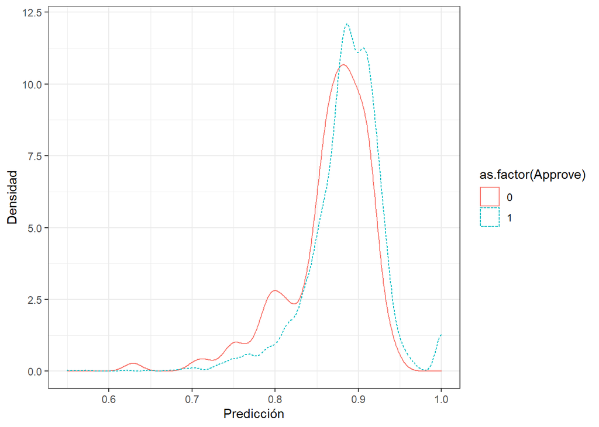

```r
dfTrainLR$pred <- predict(modeloLR, newdata= dfTrainLR, type="response")
dfTestLR$pred <- predict(modeloLR, newdata= dfTestLR, type="response")
ggplot(dfTrainLR) +
  geom_density(aes(x=pred, colour=as.factor(Approve), linetype=as.factor(Approve))) +
  xlab("Predicción") +
  ylab("Densidad") +
  theme_bw()
```

La distribución de predicciones nos marca que este modelo no es el adecuado, no tenemos 2 picos claramente definidos.

### 2.5 - Probamos re-entrenar el modelo

Vamos a quitar NAME_EDUCATION_TYPE y re-entrenar el modelo.

```r
predictores <- c("CODE_GENDER", "FLAG_OWN_CAR", "FLAG_OWN_REALTY", "AMT_INCOME_TOTAL", "NAME_INCOME_TYPE", "NAME_FAMILY_STATUS", "NAME_HOUSING_TYPE", "FLAG_WORK_PHONE", "FLAG_PHONE", "FLAG_EMAIL", "OCCUPATION_TYPE", "CNT_FAM_MEMBERS", "AGE", "YEARS_EMPLOYED")
print("Predictores:")
```

```
## [1] "Predictores:"
```

```r
print(predictores)
```

```
##  [1] "CODE_GENDER"        "FLAG_OWN_CAR"       "FLAG_OWN_REALTY"
##  [4] "AMT_INCOME_TOTAL"   "NAME_INCOME_TYPE"   "NAME_FAMILY_STATUS"
##  [7] "NAME_HOUSING_TYPE"  "FLAG_WORK_PHONE"    "FLAG_PHONE"
## [10] "FLAG_EMAIL"         "OCCUPATION_TYPE"    "CNT_FAM_MEMBERS"
## [13] "AGE"                "YEARS_EMPLOYED"
```

```r
formula <- paste(objetivo, paste(predictores, collapse = " + "), sep=" ~ ")
modeloLR <- glm(formula, data=dfTrainLR, family=binomial(link="logit"))
```

Visualizamos el summary del modelo

```r
summary(modeloLR)
```

```
##
## Call:
## glm(formula = formula, family = binomial(link = "logit"), data = dfTrainLR)
##
## Deviance Residuals:
##     Min       1Q   Median       3Q      Max
## -2.4006  -0.9577   0.5285   0.8724   2.3462
##
## Coefficients:
##                                          Estimate Std. Error z value Pr(>|z|)
## (Intercept)                             1.565e+00  7.581e-01   2.064 0.038993
## CODE_GENDERM                            2.761e-01  9.452e-02   2.921 0.003486
## FLAG_OWN_CARY                          -2.232e-01  8.429e-02  -2.648 0.008102
## FLAG_OWN_REALTYY                        6.690e-01  8.299e-02   8.061 7.57e-16
## AMT_INCOME_TOTAL                        9.006e-08  4.262e-07   0.211 0.832648
## NAME_INCOME_TYPEPensioner              -1.147e+00  1.307e-01  -8.776  < 2e-16
## NAME_INCOME_TYPEState servant           6.201e-01  2.134e-01   2.906 0.003658
## NAME_INCOME_TYPEWorking                -7.568e-02  1.056e-01  -0.717 0.473402
## NAME_FAMILY_STATUSMarried              -6.770e-01  1.770e-01  -3.825 0.000131
## NAME_FAMILY_STATUSSeparated             3.843e-02  2.591e-01   0.148 0.882091
## NAME_FAMILY_STATUSSingle / not married -4.059e-01  2.157e-01  -1.882 0.059808
## NAME_FAMILY_STATUSWidow                 9.614e-01  2.964e-01   3.244 0.001179
## NAME_HOUSING_TYPEHouse / apartment     -4.293e-01  6.472e-01  -0.663 0.507136
## NAME_HOUSING_TYPEMunicipal apartment   -1.675e+00  6.679e-01  -2.508 0.012141
## NAME_HOUSING_TYPEOffice apartment       1.449e+01  3.503e+02   0.041 0.967014
## NAME_HOUSING_TYPERented apartment       1.267e-01  7.363e-01   0.172 0.863416
## NAME_HOUSING_TYPEWith parents          -1.131e-01  6.777e-01  -0.167 0.867433
## FLAG_WORK_PHONE1                       -2.052e-01  1.024e-01  -2.003 0.045166
## FLAG_PHONE1                             2.445e-01  8.837e-02   2.767 0.005657
## FLAG_EMAIL1                             2.892e-01  1.562e-01   1.852 0.064057
## OCCUPATION_TYPEAccountants              6.442e-01  2.685e-01   2.399 0.016418
## OCCUPATION_TYPECleaning staff          -1.728e-01  3.236e-01  -0.534 0.593317
## OCCUPATION_TYPECooking staff           -1.711e+00  2.178e-01  -7.858 3.91e-15
## OCCUPATION_TYPECore staff               2.690e-01  1.666e-01   1.615 0.106349
## OCCUPATION_TYPEDrivers                  4.805e-01  1.988e-01   2.417 0.015649
## OCCUPATION_TYPEHigh skill tech staff    1.040e-01  2.190e-01   0.475 0.634961
## OCCUPATION_TYPEHR staff                 7.066e-01  8.971e-01   0.788 0.430886
## OCCUPATION_TYPEIT staff                -1.429e+00  7.034e-01  -2.032 0.042187
## OCCUPATION_TYPELaborers                 3.978e-01  1.308e-01   3.042 0.002353
## OCCUPATION_TYPELow-skill Laborers      -2.116e-01  4.271e-01  -0.495 0.620345
```

[output cut: 48 more lines]

```
## OCCUPATION_TYPESecurity staff
## OCCUPATION_TYPEWaiters/barmen staff
## CNT_FAM_MEMBERS
## AGE                                    **
## YEARS_EMPLOYED                         ***
## ---
## Signif. codes:  0 '***' 0.001 '**' 0.01 '*' 0.05 '.' 0.1 ' ' 1
##
## (Dispersion parameter for binomial family taken to be 1)
##
##     Null deviance: 4933.8  on 3590  degrees of freedom
## Residual deviance: 4067.5  on 3550  degrees of freedom
## AIC: 4149.5
##
## Number of Fisher Scoring iterations: 14
```

Las variables AMT_INCOME_TOTAL y CNT_FAM_MEMBERS no parecen tener gran capacidad de predicción.

Visualizamos el Factor de Inflación de Varianza:

```r
vif(modeloLR)
```

```
##                           CODE_GENDERM                          FLAG_OWN_CARY
##                               1.346555                               1.171047
##                       FLAG_OWN_REALTYY                       AMT_INCOME_TOTAL
##                               1.143210                               1.212120
##              NAME_INCOME_TYPEPensioner          NAME_INCOME_TYPEState servant
##                               2.512364                               1.244086
##                NAME_INCOME_TYPEWorking              NAME_FAMILY_STATUSMarried
##                               1.909110                               3.849730
##            NAME_FAMILY_STATUSSeparated NAME_FAMILY_STATUSSingle / not married
##                               1.884774                               3.172434
##                NAME_FAMILY_STATUSWidow     NAME_HOUSING_TYPEHouse / apartment
##                               1.642431                              27.395890
##   NAME_HOUSING_TYPEMunicipal apartment      NAME_HOUSING_TYPEOffice apartment
##                              15.050556                               1.000003
##      NAME_HOUSING_TYPERented apartment          NAME_HOUSING_TYPEWith parents
##                               4.331351                              11.934803
##                       FLAG_WORK_PHONE1                            FLAG_PHONE1
##                               1.255330                               1.102759
##                            FLAG_EMAIL1             OCCUPATION_TYPEAccountants
##                               1.047826                               1.088740
##          OCCUPATION_TYPECleaning staff           OCCUPATION_TYPECooking staff
##                               1.063230                               1.177455
##              OCCUPATION_TYPECore staff                 OCCUPATION_TYPEDrivers
##                               1.216715                               1.229416
##   OCCUPATION_TYPEHigh skill tech staff                OCCUPATION_TYPEHR staff
##                               1.108726                               1.010786
##                OCCUPATION_TYPEIT staff                OCCUPATION_TYPELaborers
##                               1.034078                               1.383452
##      OCCUPATION_TYPELow-skill Laborers                OCCUPATION_TYPEManagers
##                               1.040421                               1.284795
##          OCCUPATION_TYPEMedicine staff   OCCUPATION_TYPEPrivate service staff
##                               1.127408                               1.000000
##           OCCUPATION_TYPERealty agents             OCCUPATION_TYPESales staff
##                               1.039742                               1.235211
##             OCCUPATION_TYPESecretaries          OCCUPATION_TYPESecurity staff
##                               1.000000                               1.087756
##    OCCUPATION_TYPEWaiters/barmen staff                        CNT_FAM_MEMBERS
##                               1.017612                               1.647904
##                                    AGE                         YEARS_EMPLOYED
##                               1.982217                               1.147302
```

#### 2.5.1 - Evaluamos el modelo

##### 2.5.1.1 - Plotear distribución de predicciones

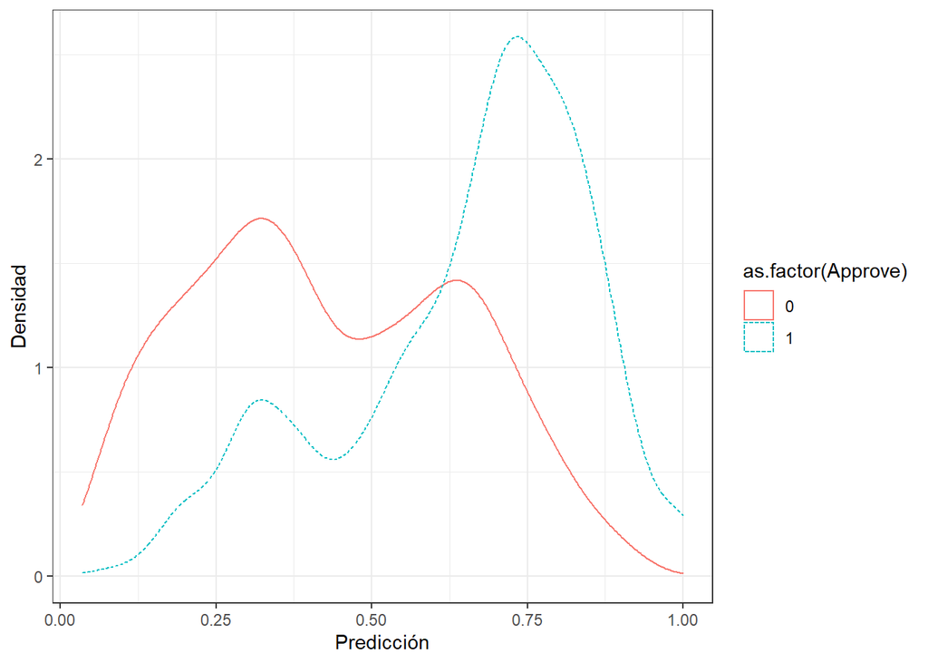

```r
dfTrainLR$pred <- predict(modeloLR, newdata= dfTrainLR, type="response")
dfTestLR$pred <- predict(modeloLR, newdata= dfTestLR, type="response")
ggplot(dfTrainLR) +
  geom_density(aes(x=pred, colour=as.factor(Approve), linetype=as.factor(Approve))) +
  xlab("Predicción") +
  ylab("Densidad") +
  theme_bw()
```

##### 2.5.1.2 - Matriz de Confusión

Probamos con un umbral del 50%.

```r
thresh <- 0.50
predObj <-prediction(dfTrainLR$pred, dfTrainLR$Approve)
precObj <- performance(predObj, measure = "prec")
recObj <- performance(predObj, measure = "rec")
precision <- (precObj@y.values)[[1]]
prec.x <- (precObj@x.values)[[1]]
recall <- (recObj@y.values)[[1]]
pnull <- (length(which(dfTrainLR$Approve == 1)) / length(which(dfTrainLR$Approve != 2)))
pnull
```

```
## [1] 0.5555556
```

```r
ctab.test <- table(prediccion=as.numeric(dfTestLR$pred > thresh), datos=dfTestLR$Approve)
ctab.test
```

```
##           datos
## prediccion    0    1
##          0   17 1050
##          1   42 3826
```

```r
precision <- ctab.test[2,2]/sum(ctab.test[2,])
paste("Precision:", precision)
```

```
## [1] "Precision: 0.989141675284385"
```

```r
recall <- ctab.test[2,2]/sum(ctab.test[,2])
paste("Recall:",recall)
```

```
## [1] "Recall: 0.784659557013946"
```

```r
enrich <- precision / pnull
paste("Enrich:",enrich)
```

```
## [1] "Enrich: 1.78045501551189"
```

```r
PorcFalsosDetect <- ctab.test[1,1]/sum(ctab.test[,1])
PorcPositivosRech <- ctab.test[1,2]/sum(ctab.test[,2])
paste("% Falsos detectados: ", round(PorcFalsosDetect * 100, digits=2))
```

```
## [1] "% Falsos detectados:  28.81"
```

```r
paste("% Creditos buenos rechazados: ", round(PorcPositivosRech * 100, digits=2))
```

```
## [1] "% Creditos buenos rechazados:  21.53"
```

##### 2.5.1.3 - Curva ROC

Antes de decidir ajustar el umbral graficamos la curva ROC para entender las capacidades de predicción del modelo.

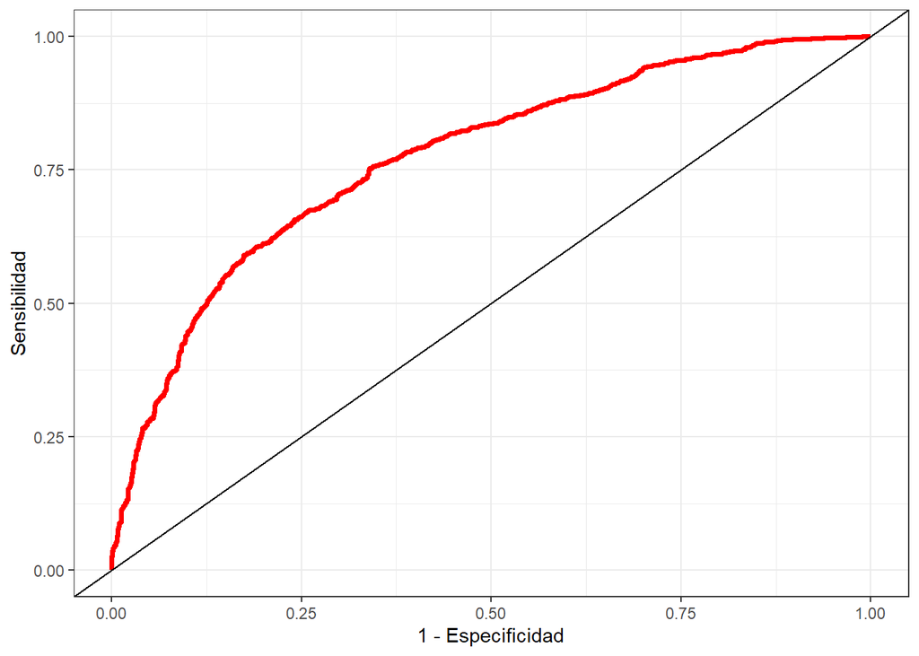

```r
sensObj <- performance(predObj, measure="sens")
specObj <- performance(predObj, measure="spec")
sensitivity <- (sensObj@y.values)[[1]]
specificity <- (specObj@y.values)[[1]]
dfplot <- data.frame(specm1=1-specificity, sens=sensitivity)
fig <- ggplot(dfplot, aes(x=specm1, y=sens))
fig <- fig + geom_line(color="red", size=1.25)
fig <- fig + geom_abline(aes(slope=1, intercept=0))
fig <- fig + theme_bw()
fig <- fig + xlab("1 - Especificidad")
fig <- fig + ylab("Sensibilidad")
fig
```

### 2.6 - Probamos re-entrenar el modelo

Vamos a quitar AMT_INCOME_TOTAL y CNT_FAM_MEMBERS para re-entrenar el modelo.

```r
predictores <- c("CODE_GENDER", "FLAG_OWN_CAR", "FLAG_OWN_REALTY", "NAME_INCOME_TYPE", "NAME_FAMILY_STATUS", "NAME_HOUSING_TYPE", "FLAG_WORK_PHONE", "FLAG_PHONE", "FLAG_EMAIL", "OCCUPATION_TYPE", "AGE", "YEARS_EMPLOYED")

print("Predictores:")
```

```
## [1] "Predictores:"
```

```r
print(predictores)
```

```
##  [1] "CODE_GENDER"        "FLAG_OWN_CAR"       "FLAG_OWN_REALTY"
##  [4] "NAME_INCOME_TYPE"   "NAME_FAMILY_STATUS" "NAME_HOUSING_TYPE"
##  [7] "FLAG_WORK_PHONE"    "FLAG_PHONE"         "FLAG_EMAIL"
## [10] "OCCUPATION_TYPE"    "AGE"                "YEARS_EMPLOYED"
```

```r
formula <- paste(objetivo, paste(predictores, collapse = " + "), sep=" ~ ")
modeloLR <- glm(formula, data=dfTrainLR, family=binomial(link="logit"))
```

Visualizamos el summary del modelo

```r
summary(modeloLR)
```

```
##
## Call:
## glm(formula = formula, family = binomial(link = "logit"), data = dfTrainLR)
##
## Deviance Residuals:
##     Min       1Q   Median       3Q      Max
## -2.3804  -0.9568   0.5289   0.8761   2.3468
##
## Coefficients:
##                                          Estimate Std. Error z value Pr(>|z|)
## (Intercept)                              1.286427   0.703550   1.828 0.067477
## CODE_GENDERM                             0.278096   0.093537   2.973 0.002948
## FLAG_OWN_CARY                           -0.225276   0.083467  -2.699 0.006955
## FLAG_OWN_REALTYY                         0.666858   0.082773   8.056 7.85e-16
## NAME_INCOME_TYPEPensioner               -1.154225   0.129735  -8.897  < 2e-16
## NAME_INCOME_TYPEState servant            0.615945   0.213143   2.890 0.003855
## NAME_INCOME_TYPEWorking                 -0.081450   0.104595  -0.779 0.436148
## NAME_FAMILY_STATUSMarried               -0.682473   0.176975  -3.856 0.000115
## NAME_FAMILY_STATUSSeparated              0.103433   0.253103   0.409 0.682788
## NAME_FAMILY_STATUSSingle / not married  -0.328410   0.206167  -1.593 0.111175
## NAME_FAMILY_STATUSWidow                  1.028951   0.290940   3.537 0.000405
## NAME_HOUSING_TYPEHouse / apartment      -0.390213   0.642929  -0.607 0.543898
## NAME_HOUSING_TYPEMunicipal apartment    -1.638753   0.663758  -2.469 0.013553
## NAME_HOUSING_TYPEOffice apartment       14.483540 351.143744   0.041 0.967099
## NAME_HOUSING_TYPERented apartment        0.176744   0.732305   0.241 0.809281
## NAME_HOUSING_TYPEWith parents           -0.057301   0.672398  -0.085 0.932087
## FLAG_WORK_PHONE1                        -0.207036   0.101906  -2.032 0.042191
## FLAG_PHONE1                              0.248873   0.087739   2.837 0.004561
## FLAG_EMAIL1                              0.298203   0.155759   1.915 0.055553
## OCCUPATION_TYPEAccountants               0.652304   0.268458   2.430 0.015106
## OCCUPATION_TYPECleaning staff           -0.184161   0.323039  -0.570 0.568618
## OCCUPATION_TYPECooking staff            -1.714350   0.217791  -7.872 3.50e-15
## OCCUPATION_TYPECore staff                0.259691   0.165922   1.565 0.117551
## OCCUPATION_TYPEDrivers                   0.486079   0.198805   2.445 0.014485
## OCCUPATION_TYPEHigh skill tech staff     0.108569   0.218927   0.496 0.619956
## OCCUPATION_TYPEHR staff                  0.714950   0.892653   0.801 0.423174
## OCCUPATION_TYPEIT staff                 -1.414645   0.701948  -2.015 0.043872
## OCCUPATION_TYPELaborers                  0.397654   0.130730   3.042 0.002352
## OCCUPATION_TYPELow-skill Laborers       -0.222830   0.426561  -0.522 0.601401
## OCCUPATION_TYPEManagers                  0.180543   0.158233   1.141 0.253873
```

[output cut: 44 more lines]

```
## OCCUPATION_TYPESecretaries
## OCCUPATION_TYPESecurity staff
## OCCUPATION_TYPEWaiters/barmen staff
## AGE                                    **
## YEARS_EMPLOYED                         ***
## ---
## Signif. codes:  0 '***' 0.001 '**' 0.01 '*' 0.05 '.' 0.1 ' ' 1
##
## (Dispersion parameter for binomial family taken to be 1)
##
##     Null deviance: 4933.8  on 3590  degrees of freedom
## Residual deviance: 4069.1  on 3552  degrees of freedom
## AIC: 4147.1
##
## Number of Fisher Scoring iterations: 14
```

Visualizamos el Factor de Inflación de Varianza:

```r
vif(modeloLR)
```

```
##                           CODE_GENDERM                          FLAG_OWN_CARY
##                               1.319198                               1.148706
##                       FLAG_OWN_REALTYY              NAME_INCOME_TYPEPensioner
##                               1.137852                               2.474546
##          NAME_INCOME_TYPEState servant                NAME_INCOME_TYPEWorking
##                               1.241454                               1.875468
##              NAME_FAMILY_STATUSMarried            NAME_FAMILY_STATUSSeparated
##                               3.862158                               1.808004
## NAME_FAMILY_STATUSSingle / not married                NAME_FAMILY_STATUSWidow
##                               2.918244                               1.586544
##     NAME_HOUSING_TYPEHouse / apartment   NAME_HOUSING_TYPEMunicipal apartment
##                              27.083849                              14.882085
##      NAME_HOUSING_TYPEOffice apartment      NAME_HOUSING_TYPERented apartment
##                               1.000003                               4.290258
##          NAME_HOUSING_TYPEWith parents                       FLAG_WORK_PHONE1
##                              11.780371                               1.244196
##                            FLAG_PHONE1                            FLAG_EMAIL1
##                               1.087410                               1.043592
##             OCCUPATION_TYPEAccountants          OCCUPATION_TYPECleaning staff
##                               1.087151                               1.061821
##           OCCUPATION_TYPECooking staff              OCCUPATION_TYPECore staff
##                               1.177201                               1.210890
##                 OCCUPATION_TYPEDrivers   OCCUPATION_TYPEHigh skill tech staff
##                               1.228323                               1.106428
##                OCCUPATION_TYPEHR staff                OCCUPATION_TYPEIT staff
##                               1.010839                               1.032053
##                OCCUPATION_TYPELaborers      OCCUPATION_TYPELow-skill Laborers
##                               1.382561                               1.037726
##                OCCUPATION_TYPEManagers          OCCUPATION_TYPEMedicine staff
##                               1.236785                               1.126244
##   OCCUPATION_TYPEPrivate service staff           OCCUPATION_TYPERealty agents
##                               1.000000                               1.036249
##             OCCUPATION_TYPESales staff             OCCUPATION_TYPESecretaries
##                               1.232990                               1.000000
##          OCCUPATION_TYPESecurity staff    OCCUPATION_TYPEWaiters/barmen staff
##                               1.085415                               1.016412
##                                    AGE                         YEARS_EMPLOYED
##                               1.752175                               1.146453
```

#### 2.6.1 - Evaluamos el modelo

##### 2.6.1.1 - Plotear distribución de predicciones

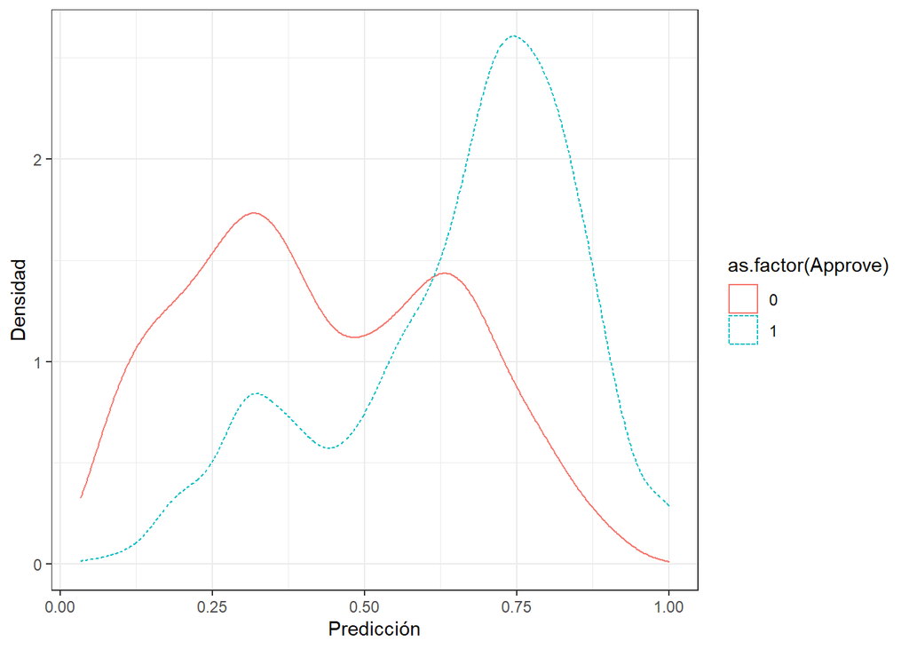

```r
dfTrainLR$pred <- predict(modeloLR, newdata= dfTrainLR, type="response")
dfTestLR$pred <- predict(modeloLR, newdata= dfTestLR, type="response")
ggplot(dfTrainLR) +
  geom_density(aes(x=pred, colour=as.factor(Approve), linetype=as.factor(Approve))) +
  xlab("Predicción") +
  ylab("Densidad") +
  theme_bw()
```

##### 2.6.1.2 - Matriz de Confusión

Probamos con un umbral del 50%.

```r
thresh <- 0.50
predObj <-prediction(dfTrainLR$pred, dfTrainLR$Approve)
precObj <- performance(predObj, measure = "prec")
recObj <- performance(predObj, measure = "rec")
precision <- (precObj@y.values)[[1]]
prec.x <- (precObj@x.values)[[1]]
recall <- (recObj@y.values)[[1]]
pnull <- (length(which(dfTrainLR$Approve == 1)) / length(which(dfTrainLR$Approve != 2)))
pnull
```

```
## [1] 0.5555556
```

```r
ctab.test <- table(prediccion=as.numeric(dfTestLR$pred > thresh), datos=dfTestLR$Approve)
ctab.test
```

```
##           datos
## prediccion    0    1
##          0   18 1049
##          1   41 3827
```

```r
precision <- ctab.test[2,2]/sum(ctab.test[2,])
paste("Precision:", precision)
```

```
## [1] "Precision: 0.989400206825233"
```

```r
recall <- ctab.test[2,2]/sum(ctab.test[,2])
paste("Recall:",recall)
```

```
## [1] "Recall: 0.784864643150123"
```

```r
enrich <- precision / pnull
paste("Enrich:",enrich)
```

```
## [1] "Enrich: 1.78092037228542"
```

```r
PorcFalsosDetect <- ctab.test[1,1]/sum(ctab.test[,1])
PorcPositivosRech <- ctab.test[1,2]/sum(ctab.test[,2])
paste("% Falsos detectados: ", round(PorcFalsosDetect * 100, digits=2))
```

```
## [1] "% Falsos detectados:  30.51"
```

```r
paste("% Creditos buenos rechazados: ", round(PorcPositivosRech * 100, digits=2))
```

```
## [1] "% Creditos buenos rechazados:  21.51"
```

##### 2.6.1.3 - Curva ROC

Antes de decidir ajustar el umbral graficamos la curva ROC para entender las capacidades de predicción del modelo.

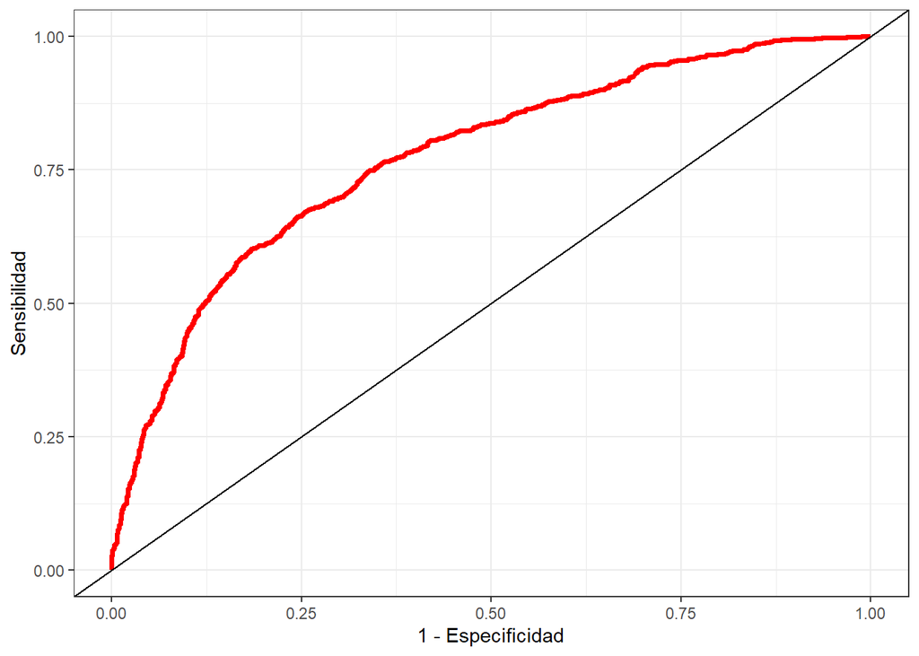

```r
sensObj <- performance(predObj, measure="sens")
specObj <- performance(predObj, measure="spec")
sensitivity <- (sensObj@y.values)[[1]]
specificity <- (specObj@y.values)[[1]]
dfplot <- data.frame(specm1=1-specificity, sens=sensitivity)
fig <- ggplot(dfplot, aes(x=specm1, y=sens))
fig <- fig + geom_line(color="red", size=1.25)
fig <- fig + geom_abline(aes(slope=1, intercept=0))
fig <- fig + theme_bw()
fig <- fig + xlab("1 - Especificidad")
fig <- fig + ylab("Sensibilidad")
fig
```

## 3 - Ajustamos el umbral del modelo seleccionado (2.6)

Seleccionamos el modelo 2.6 porque de los que mejor distribución de probabilidades y curva ROC tienen es el mas simple, o sea, que tiene menor cantidad de predictores.

### 3.1 - Rearmamos el modelo

```r
predictores <- c("CODE_GENDER", "FLAG_OWN_CAR", "FLAG_OWN_REALTY", "NAME_INCOME_TYPE", "NAME_FAMILY_STATUS", "NAME_HOUSING_TYPE", "FLAG_WORK_PHONE", "FLAG_PHONE", "FLAG_EMAIL", "OCCUPATION_TYPE", "AGE", "YEARS_EMPLOYED")
formula <- paste(objetivo, paste(predictores, collapse = " + "), sep=" ~ ")
modeloLR <- glm(formula, data=dfTrainLR, family=binomial(link="logit"))
dfTrainLR$pred <- predict(modeloLR, newdata= dfTrainLR, type="response")
dfTestLR$pred <- predict(modeloLR, newdata= dfTestLR, type="response")
```

### 3.2 - Graficamos la precisión y la exhaustividad

```r
predObj <-prediction(dfTrainLR$pred, dfTrainLR$Approve)
precObj <- performance(predObj, measure = "prec")
recObj <- performance(predObj, measure = "rec")
precision <- (precObj@y.values)[[1]]
prec.x <- (precObj@x.values)[[1]]
recall <- (recObj@y.values)[[1]]
pnull <- (length(which(dfTrainLR$Approve == 1)) / length(which(dfTrainLR$Approve != 2)))
pnull
```

```
## [1] 0.5555556
```

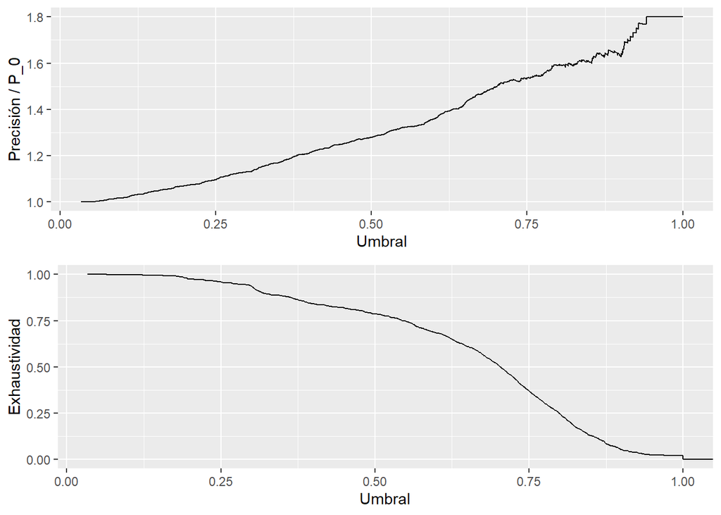

```r
# Data for the plot
dfplot <- data.frame(threshold=prec.x, precision=precision, recall=recall)
p1 <- ggplot(dfplot, aes(x=threshold)) +
  geom_line(aes(y=precision/pnull)) +
  xlab("Umbral") +
  ylab("Precisión / P_0")
p2 <- ggplot(dfplot, aes(x=threshold)) +
  geom_line(aes(y=recall)) +
  xlab("Umbral") +
  ylab("Exhaustividad")
nplot(list(p1, p2))
```

### 3.3 - Creamos la matriz de confusión

Tomamos un umbral del 50% para ir ajustando.

```r
thresh <- 0.50
ctab.test <- table(prediccion=as.numeric(dfTestLR$pred > thresh), datos=dfTestLR$Approve)
ctab.test
```

```
##           datos
## prediccion    0    1
##          0   18 1049
##          1   41 3827
```

```r
precision <- ctab.test[2,2]/sum(ctab.test[2,])
paste("Precision:", precision)
```

```
## [1] "Precision: 0.989400206825233"
```

```r
recall <- ctab.test[2,2]/sum(ctab.test[,2])
paste("Recall:",recall)
```

```
## [1] "Recall: 0.784864643150123"
```

```r
enrich <- precision / pnull
paste("Enrich:",enrich)
```

```
## [1] "Enrich: 1.78092037228542"
```

```r
PorcFalsosDetect <- ctab.test[1,1]/sum(ctab.test[,1])
PorcPositivosRech <- ctab.test[1,2]/sum(ctab.test[,2])
paste("% Falsos detectados: ", round(PorcFalsosDetect * 100, digits=2))
```

```
## [1] "% Falsos detectados:  30.51"
```

```r
paste("% Creditos buenos rechazados: ", round(PorcPositivosRech * 100, digits=2))
```

```
## [1] "% Creditos buenos rechazados:  21.51"
```

### 3.4 - Ajustamos el Umbral del modelo

Probamos con 45%, 55%, 60% y 65%. El umbral que más cerca está de las necesidades de negocio es del 55%.

```r
thresh <- 0.55
ctab.test <- table(prediccion=as.numeric(dfTestLR$pred > thresh), datos=dfTestLR$Approve)
ctab.test
```

```
##           datos
## prediccion    0    1
##          0   21 1258
##          1   38 3618
```

```r
precision <- ctab.test[2,2]/sum(ctab.test[2,])
paste("Precision:", precision)
```

```
## [1] "Precision: 0.989606126914661"
```

```r
recall <- ctab.test[2,2]/sum(ctab.test[,2])
paste("Recall:",recall)
```

```
## [1] "Recall: 0.742001640689089"
```

```r
enrich <- precision / pnull
paste("Enrich:",enrich)
```

```
## [1] "Enrich: 1.78129102844639"
```

```r
PorcFalsosDetect <- ctab.test[1,1]/sum(ctab.test[,1])
PorcPositivosRech <- ctab.test[1,2]/sum(ctab.test[,2])
paste("% Falsos detectados: ", round(PorcFalsosDetect * 100, digits=2))
```

```
## [1] "% Falsos detectados:  35.59"
```

```r
paste("% Creditos buenos rechazados: ", round(PorcPositivosRech * 100, digits=2))
```

```
## [1] "% Creditos buenos rechazados:  25.8"
```

# Análisis de Resultados y Conclusiones

Los objetivos que nos planteó el negocio fueron 2:

- detectar 2/3 de los créditos malos
- detectar 3/4 de los créditos buenos

De acuerdo con el análisis realizado no logramos ajustar un modelo que cumpla con las necesidades de negocio propuestas.

Se observa un modelo que, si bien es un 78% mejor que el modelo nulo, a los fines de negocio tiene una muy baja detección de créditos malos y un alto rechazo de créditos buenos.

Por todo esto, entendemos que el proceso de Ciencia de Datos aplicado hasta el momento no logró un modelo que cumpla con los objetivos planteados.

Para una mejor evaluación de las capacidades predictivas del modelo, cuando se utilice para predicciones de datos no utilizados durante la etapa de entrenamiento, se podría aplicar cross-validation.

Existen otros algoritmos de clasificación que podrían probarse con el set de datos actual como Árboles de Decisión, Random Forest o Support Vector Machines, y verificar si mejoran la capacidad de predicción.

Otra opción sería tratar de conseguir un set de datos con mayor cantidad de deudores. En este set solo se tiene información de 382 casos. Como mencionamos anteriormente, la media de deudores del mercado de tarjetas de Estados Unidos es de aproximadamente 3%, lo que implicaría conseguir un set de datos mucho más grande.